# Comunicación con R Markdown del análisis de datos 911 CDMX

Antonio Toro

2026-06-13

# 1 Introducción

Este documento presenta la comunicación técnica del análisis exploratorio del conjunto de datos de llamadas cerradas al **911 de la Ciudad de México**. El proyecto se desarrolló en R y se orientó a transformar registros administrativos masivos en resultados descriptivos, visualizaciones y tablas interpretables.

El propósito del reporte es comunicar de manera reproducible los principales hallazgos del análisis, integrando narrativa técnica, resultados agregados, tablas y gráficos generados durante el procesamiento. El alcance del análisis es **exploratorio y descriptivo**, por lo que los resultados permiten identificar patrones territoriales, temporales y operativos, pero no establecer relaciones causales.

# 2 Comunicación reproducible con R Markdown

R Markdown se utiliza como medio de comunicación reproducible porque permite integrar en un mismo documento la explicación del análisis, los insumos generados por R y la publicación final en formato HTML. En este proyecto, el archivo `index.Rmd` funciona como documento fuente y se renderiza como `index.html` para su publicación en GitHub Pages o Netlify.

```
Datos 911
  ↓
Procesamiento con R
  ↓
CSV y PNG agregados
  ↓
dashboard_911/index.Rmd
  ↓
dashboard_911/index.html
  ↓
docs/index.html
  ↓
GitHub Pages / Netlify
```

# 3 Relevancia del dataset 911 CDMX

El dataset de llamadas cerradas al **911 de la Ciudad de México** constituye un registro administrativo de alto valor público sobre la demanda ciudadana de atención inmediata. Al reunir reportes relacionados con delitos, emergencias, urgencias médicas, faltas cívicas, servicios y falsas alarmas, permite identificar patrones territoriales, temporales y operativos útiles para reconocer zonas de mayor concentración, horarios críticos y necesidades prioritarias de atención.

En este sentido, el dataset aporta evidencia descriptiva para apoyar diagnósticos urbanos, orientar recursos institucionales y fortalecer la toma de decisiones basada en datos.

# 4 Descripción y calidad de los datos

El análisis integra los archivos públicos disponibles de llamadas cerradas al 911. La base procesada permite construir indicadores por periodo, alcaldía, categoría, día de la semana, hora del reporte y duración entre creación y cierre del folio.

Diagnóstico general de calidad del dataset 911 CDMX

| indicador | valor |
| --- | --- |
| registros | 1671036 |
| columnas | 34 |
| duplicados_fila_completa | 0 |
| folios_duplicados | 1 |
| duraciones_negativas | 48 |
| datetime_creacion_na | 0 |
| datetime_cierre_na | 0 |

Rango temporal de los archivos procesados

| variable | minimo | maximo |
| --- | --- | --- |
| fecha_creacion | 2020-03-08 | 2022-05-01 |
| fecha_cierre | 2021-01-01 | 2022-05-01 |

# 5 Metodología de procesamiento en R

El procesamiento se organiza como un flujo estructurado de ciencia de datos. Primero se cargan e integran los archivos originales; después se normalizan textos y categorías; posteriormente se construyen variables temporales con `lubridate`; finalmente se agrupan los datos con `dplyr` y se completan combinaciones con `tidyr` para producir tablas y gráficos de las tareas solicitadas.

```
Carga de datos
  ↓
Integración de archivos
  ↓
Limpieza y normalización
  ↓
Construcción de fechas y horas
  ↓
Agrupamientos y resúmenes
  ↓
Exportación de CSV y PNG
  ↓
Comunicación en R Markdown y Shiny
```

# 6 Tarea 1. Incidentes por mes, alcaldía y categoría

Agrupación de incidentes por mes, alcaldía y categoría; cálculo de promedio mensual por categoría.

## 6.1 Datos utilizados

- **Insumos:** `02_tarea1_conteo_mes_alcaldia_categoria.csv` y `02_tarea1_promedio_mensual_por_alcaldia_categoria.csv`.
- **Estructura:** combinaciones de `mes_cierre`, alcaldía y `categoria_etiqueta` con conteos y promedios mensuales.
- **Origen:** folios cerrados del 911 CDMX previamente integrados y agregados por el pipeline EDA.

## 6.2 Objetivos específicos

- Identificar patrones territoriales y mensuales de llamadas cerradas al 911.
- Comparar el volumen de incidentes por alcaldía y categoría para ubicar concentraciones relevantes.
- Distinguir tendencias de volumen absoluto sin asumir causalidad ni riesgo ajustado por población.

## 6.3 Hallazgos e interpretación

- Iztapalapa concentra los mayores promedios mensuales, principalmente en DELITO, FALTA CÍVICA y SERVICIO.
- Gustavo A. Madero y Cuauhtémoc también aparecen entre las alcaldías con mayor volumen absoluto.
- El resultado debe interpretarse como concentración de llamadas, no como mayor riesgo territorial sin ajustes demográficos o urbanos.

## 6.4 Visualización y tabla de resultados

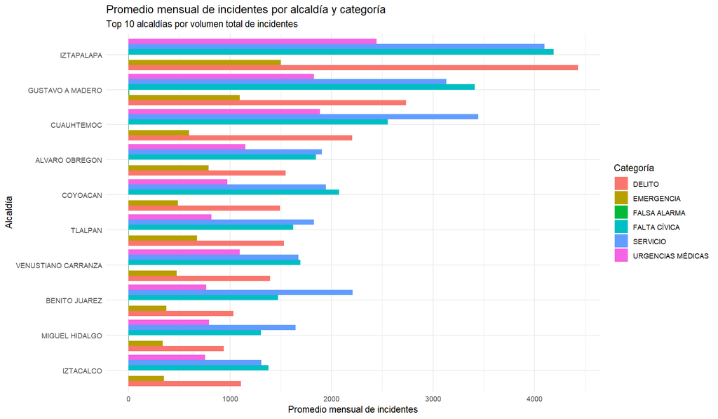

Promedio mensual por alcaldía y categoría

| alcaldia | categoria_etiqueta | promedio_mensual | total_periodo | meses_observados |
| --- | --- | --- | --- | --- |
| IZTAPALAPA | DELITO | 4426.588 | 75252 | 17 |
| IZTAPALAPA | FALTA CÍVICA | 4187.824 | 71193 | 17 |
| IZTAPALAPA | SERVICIO | 4096.471 | 69640 | 17 |
| CUAUHTEMOC | SERVICIO | 3443.588 | 58541 | 17 |
| GUSTAVO A MADERO | FALTA CÍVICA | 3411.588 | 57997 | 17 |
| GUSTAVO A MADERO | SERVICIO | 3132.941 | 53260 | 17 |
| GUSTAVO A MADERO | DELITO | 2735.529 | 46504 | 17 |
| CUAUHTEMOC | FALTA CÍVICA | 2553.529 | 43410 | 17 |
| IZTAPALAPA | URGENCIAS MÉDICAS | 2442.059 | 41515 | 17 |
| BENITO JUAREZ | SERVICIO | 2206.471 | 37510 | 17 |
| CUAUHTEMOC | DELITO | 2205.235 | 37489 | 17 |
| COYOACAN | FALTA CÍVICA | 2073.353 | 35247 | 17 |
| COYOACAN | SERVICIO | 1945.941 | 33081 | 17 |
| ALVARO OBREGON | SERVICIO | 1904.294 | 32373 | 17 |
| CUAUHTEMOC | URGENCIAS MÉDICAS | 1886.294 | 32067 | 17 |

Conteo mensual por alcaldía y categoría

| mes_cierre | alcaldia | categoria_etiqueta | total_incidentes | promedio_mensual_categoria |
| --- | --- | --- | --- | --- |
| 2021-01-01 | ALVARO OBREGON | DELITO | 1492 | 1547.588 |
| 2021-02-01 | ALVARO OBREGON | DELITO | 1523 | 1547.588 |
| 2021-03-01 | ALVARO OBREGON | DELITO | 1649 | 1547.588 |
| 2021-04-01 | ALVARO OBREGON | DELITO | 1671 | 1547.588 |
| 2021-05-01 | ALVARO OBREGON | DELITO | 1631 | 1547.588 |
| 2021-06-01 | ALVARO OBREGON | DELITO | 1289 | 1547.588 |
| 2021-07-01 | ALVARO OBREGON | DELITO | 1604 | 1547.588 |
| 2021-08-01 | ALVARO OBREGON | DELITO | 1732 | 1547.588 |
| 2021-09-01 | ALVARO OBREGON | DELITO | 2071 | 1547.588 |
| 2021-10-01 | ALVARO OBREGON | DELITO | 1780 | 1547.588 |
| 2021-11-01 | ALVARO OBREGON | DELITO | 1637 | 1547.588 |
| 2021-12-01 | ALVARO OBREGON | DELITO | 1833 | 1547.588 |
| 2022-01-01 | ALVARO OBREGON | DELITO | 1460 | 1547.588 |
| 2022-02-01 | ALVARO OBREGON | DELITO | 1492 | 1547.588 |
| 2022-03-01 | ALVARO OBREGON | DELITO | 1741 | 1547.588 |

# 7 Tarea 2. Día de la semana con más incidentes

Identificación del día de la semana con más incidentes y total de llamadas asociado.

## 7.1 Datos utilizados

- **Insumos:** `03_tarea2_dia_semana_maximo.csv` y `03_tarea2_incidentes_por_dia_semana.csv`.
- **Estructura:** conteo de llamadas por `dia_semana` calculado desde `fecha_creacion`.
- **Origen:** folios cerrados del 911 CDMX agregados por comportamiento semanal.

## 7.2 Objetivos específicos

- Determinar qué día de la semana concentra más llamadas al 911.
- Reconocer comportamientos semanales útiles para planeación operativa.
- Comparar la carga de llamadas entre fines de semana y días laborales.

## 7.3 Hallazgos e interpretación

- Domingo es el día con mayor número de llamadas, seguido por sábado.
- Sábado y domingo concentran cerca de cuatro de cada diez llamadas del periodo analizado.
- El patrón sugiere mayor presión operativa en fines de semana, aunque no permite establecer causalidad.

## 7.4 Visualización y tabla de resultados

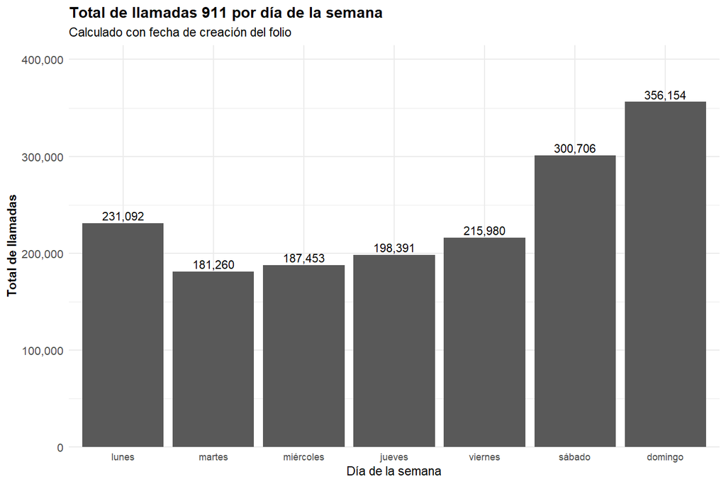

Incidentes por día de la semana

| dia_semana | total_llamadas |
| --- | --- |
| domingo | 356154 |
| sábado | 300706 |
| lunes | 231092 |
| viernes | 215980 |
| jueves | 198391 |
| miércoles | 187453 |
| martes | 181260 |

Día de la semana con mayor número de incidentes

| dia_semana | total_llamadas |
| --- | --- |
| domingo | 356154 |

# 8 Tarea 3. Distribución horaria para DELITO, EMERGENCIA y URGENCIAS MÉDICAS

Distribución horaria para las categorías DELITO, EMERGENCIA y URGENCIAS MÉDICAS.

## 8.1 Datos utilizados

- **Insumos:** `04_tarea3_distribucion_hora_categoria.csv` y `04_tarea3_hora_pico_por_categoria.csv`.
- **Estructura:** conteos por hora de 0 a 23 para DELITO, EMERGENCIA y URGENCIAS MÉDICAS.
- **Origen:** registros 911 procesados con `hora_reporte` y categoría normalizada.

## 8.2 Objetivos específicos

- Analizar la distribución horaria de DELITO, EMERGENCIA y URGENCIAS MÉDICAS.
- Identificar horas pico por categoría para reconocer comportamientos temporales diferenciados.
- Apoyar una lectura operativa por franjas horarias, no uniforme para todas las categorías.

## 8.3 Hallazgos e interpretación

- DELITO presenta mayor concentración nocturna, con pico alrededor de las 21:00.
- EMERGENCIA concentra mayor carga entre tarde y noche, con pico cercano a las 19:00.
- URGENCIAS MÉDICAS alcanza su mayor volumen alrededor de las 14:00 y mantiene demanda relevante durante tarde y noche.

## 8.4 Visualización y tabla de resultados

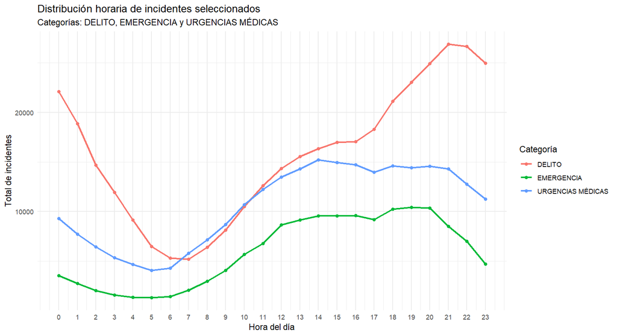

Hora pico por categoría de incidente

| categoria_etiqueta | hora_reporte | total_incidentes |
| --- | --- | --- |
| DELITO | 21 | 26890 |
| EMERGENCIA | 19 | 10439 |
| URGENCIAS MÉDICAS | 14 | 15209 |

Distribución horaria por categoría

| categoria_etiqueta | hora_reporte | total_incidentes |
| --- | --- | --- |
| DELITO | 0 | 22089 |
| DELITO | 1 | 18861 |
| DELITO | 2 | 14674 |
| DELITO | 3 | 11944 |
| DELITO | 4 | 9152 |
| DELITO | 5 | 6476 |
| DELITO | 6 | 5293 |
| DELITO | 7 | 5204 |
| DELITO | 8 | 6384 |
| DELITO | 9 | 8151 |
| DELITO | 10 | 10492 |
| DELITO | 11 | 12613 |
| DELITO | 12 | 14327 |
| DELITO | 13 | 15551 |
| DELITO | 14 | 16356 |

# 9 Tarea 4. Tiempo entre creación y cierre del incidente

Tiempo entre creación y cierre del incidente. El histograma se limita al percentil 99 para mejorar legibilidad.

## 9.1 Datos utilizados

- **Insumos:** `05_tarea4_resumen_tiempo_cierre.csv` y `05_tarea4_duraciones_negativas.csv`.
- **Estructura:** métricas de duración en minutos entre `datetime_creacion` y `datetime_cierre`.
- **Origen:** folios cerrados del 911 CDMX con fechas y horas validadas por el pipeline EDA.

## 9.2 Objetivos específicos

- Medir el tiempo transcurrido entre creación y cierre de los incidentes.
- Detectar comportamientos atípicos, valores extremos e inconsistencias temporales.
- Diferenciar el comportamiento típico del promedio afectado por casos extremos.

## 9.3 Hallazgos e interpretación

- La mediana representa mejor el cierre típico que el promedio, porque la distribución es asimétrica a la derecha.
- Existen pocos casos con duraciones negativas, por lo que deben documentarse como inconsistencias y no como tiempos reales.
- El histograma se limita al percentil 99 para mejorar la legibilidad visual y reducir distorsión por valores extremos.

## 9.4 Visualización y tabla de resultados

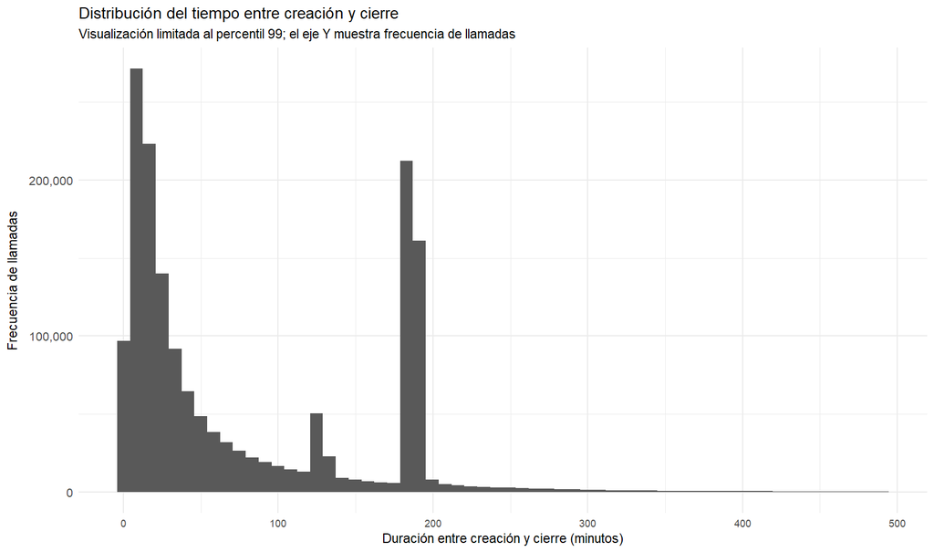

Resumen del tiempo entre creación y cierre

| metrica | valor |
| --- | --- |
| registros_totales | 1.671036e+06 |
| registros_validos_duracion | 1.670988e+06 |
| duraciones_negativas_excluidas | 4.800000e+01 |
| duraciones_na | 0.000000e+00 |
| promedio_minutos | 1.662512e+02 |
| mediana_minutos | 3.890000e+01 |
| minimo_minutos | 6.666670e-02 |
| maximo_minutos | 1.085981e+06 |
| promedio_horas | 2.770853e+00 |
| maximo_dias | 7.541536e+02 |

Duraciones negativas detectadas

| folio | periodo_archivo | fecha_creacion | hora_creacion | fecha_cierre | hora_cierre | duracion_minutos |
| --- | --- | --- | --- | --- | --- | --- |
| C5/20210525/01420 | 2021_s1 | 2021-05-25 | 12:54:09 | 2021-05-25 | 12:52:08 | -2.0166667 |
| C5/20210524/01596 | 2021_s1 | 2021-05-24 | 12:04:33 | 2021-05-24 | 12:04:23 | -0.1666667 |
| C5/20211031/01120 | 2021_s2 | 2021-10-31 | 01:58:15 | 2021-10-31 | 01:03:18 | -54.9500000 |
| C5/20211031/00898 | 2021_s2 | 2021-10-31 | 01:36:38 | 2021-10-31 | 01:33:10 | -3.4666667 |
| C5/20211031/00887 | 2021_s2 | 2021-10-31 | 01:34:47 | 2021-10-31 | 01:31:29 | -3.3000000 |
| C5/20211031/01086 | 2021_s2 | 2021-10-31 | 01:54:41 | 2021-10-31 | 01:16:43 | -37.9666667 |
| C5/20211031/00826 | 2021_s2 | 2021-10-31 | 01:27:52 | 2021-10-31 | 01:09:22 | -18.5000000 |
| C5/20211031/01056 | 2021_s2 | 2021-10-31 | 01:52:07 | 2021-10-31 | 01:20:27 | -31.6666667 |
| C5/20211031/01045 | 2021_s2 | 2021-10-31 | 01:50:25 | 2021-10-31 | 01:19:53 | -30.5333333 |
| C5/20211031/01012 | 2021_s2 | 2021-10-31 | 01:47:27 | 2021-10-31 | 01:00:30 | -46.9500000 |

# 10 Tarea 5. Porcentaje de llamadas clasificadas como FALSA ALARMA

Porcentaje de llamadas clasificadas como FALSA ALARMA y distribución general por clasificación.

## 10.1 Datos utilizados

- **Insumos:** `06_tarea5_distribucion_categorias.csv` y `06_tarea5_porcentaje_falsa_alarma.csv`.
- **Estructura:** distribución porcentual por clasificación general y cálculo específico de FALSA ALARMA.
- **Origen:** clasificación general normalizada de llamadas cerradas al 911 CDMX.

## 10.2 Objetivos específicos

- Calcular el porcentaje de llamadas clasificadas como FALSA ALARMA.
- Comparar su peso relativo frente a SERVICIO, FALTA CÍVICA, DELITO, EMERGENCIA y URGENCIAS MÉDICAS.
- Evitar confundir la clasificación general con el código de cierre del incidente.

## 10.3 Hallazgos e interpretación

- FALSA ALARMA representa una fracción mínima del total de llamadas.
- La operación se concentra principalmente en SERVICIO, FALTA CÍVICA y DELITO.
- La interpretación debe basarse en `clas_con_f_alarma`, no en una equivalencia automática con el código de cierre.

## 10.4 Visualización y tabla de resultados

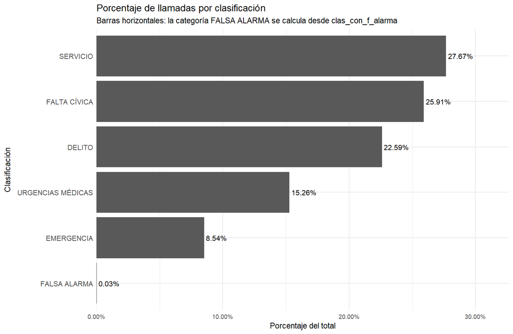

Porcentaje de llamadas clasificadas como falsa alarma

| total_llamadas | llamadas_falsa_alarma | porcentaje_falsa_alarma | codigo_cierre_f |
| --- | --- | --- | --- |
| 1671036 | 504 | 0.0301609 | 0 |

Distribución general por clasificación

| categoria_etiqueta | total_llamadas | porcentaje |
| --- | --- | --- |
| SERVICIO | 462340 | 27.6678659 |
| FALTA CÍVICA | 432994 | 25.9117099 |
| DELITO | 377511 | 22.5914343 |
| URGENCIAS MÉDICAS | 255041 | 15.2624480 |
| EMERGENCIA | 142646 | 8.5363810 |
| FALSA ALARMA | 504 | 0.0301609 |

# 11 Cierre integrado y reflexión inferencial

Los hallazgos muestran que la demanda registrada por el 911 presenta concentraciones claras en tres dimensiones: territorial, semanal y horaria. Iztapalapa, Gustavo A. Madero y Cuauhtémoc concentran los mayores volúmenes absolutos; domingo y sábado agrupan una parte importante de las llamadas; y las categorías DELITO, EMERGENCIA y URGENCIAS MÉDICAS no comparten el mismo patrón horario.

De manera inferencial, aunque el análisis no permite afirmar causas, sí sugiere que la operación del servicio podría beneficiarse de estrategias diferenciadas por territorio, día de la semana, categoría y franja horaria. La evidencia apunta a que una planeación uniforme tendría menor capacidad explicativa que una asignación sensible a patrones temporales y territoriales.

El tiempo de cierre también muestra asimetría: la mediana describe mejor el caso típico que el promedio, debido a valores extremos. Por ello, la toma de decisiones debería considerar medidas robustas y documentar inconsistencias temporales antes de interpretar los indicadores como tiempos reales de atención.

# 12 Publicación del análisis: GitHub Pages y Shiny Apps

La publicación estática del reporte se realiza mediante GitHub Pages o Netlify a partir del archivo `docs/index.html`. Esta salida comunica formalmente el análisis en un formato web navegable.

La aplicación Shiny se plantea como complemento interactivo. Su función es presentar los mismos insumos agregados mediante pestañas, KPIs, tablas y gráficos. En la arquitectura del proyecto, Shiny no debe recalcular los millones de registros originales; debe consumir únicamente los CSV y PNG generados previamente.

```
EDA en R
  ↓
dashboard_911/data/*.csv
dashboard_911/www/*.png
  ↓
dashboard_911/app.R
  ↓
Shiny local / shinyapps.io
```

# 13 Enlaces del proyecto

- **Datasets 911:**  
  https://datos.cdmx.gob.mx/dataset/llamadas-numero-de-atencion-a-emergencias-911
- **Repositorio:**  
  https://github.com/antoniot73/App_R_tidyr_lubridate_dplyr_markdown
- **Datasets CDMX:**  
  https://datos.cdmx.gob.mx/

# 14 Cierre técnico

El proyecto transforma un conjunto masivo de registros administrativos del 911 en evidencia descriptiva organizada. R permite procesar y resumir los datos; R Markdown permite documentar y publicar los resultados; y Shiny permite explorar los productos analíticos mediante una interfaz interactiva.

```
El dataset aporta evidencia.
R procesa y resume.
R Markdown comunica y documenta.
GitHub Pages / Netlify publica el reporte.
Shiny Apps permite explorar los resultados.
```

# 15 Referencias

C5 de la Ciudad de México. (s. f.). *Versión pública de la base de datos del número de atención a emergencias 9-1-1: Guía del usuario*. Gobierno de la Ciudad de México.  
https://datos.cdmx.gob.mx/dataset/llamadas-numero-de-atencion-a-emergencias-911

Xie, Y., Allaire, J. J., & Grolemund, G. (2018). *R Markdown: The definitive guide*. Chapman & Hall/CRC.